# 04_arc_len_from_unit_arc

## 04_arc_len_from_unit_arc

#### Question

1. Two concentric circles have radii $r_1=1$ meters and $r_2=3.4$ meters. A central angle subtends similar arcs on both circles: a blue arc on the smaller circle and a red arc on the larger circle. The blue arc length is 1.95 meters, as shown in the diagram below.

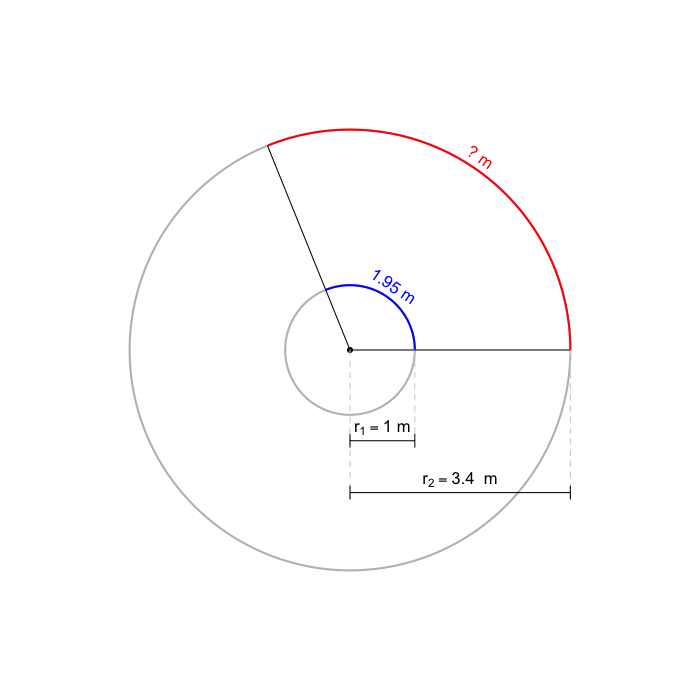

   What is the length, in meters, of the red arc? *The tolerance is set to $\pm0.01$ meters.*

#### Question

2. Two concentric circles have radii $r_1=1$ meters and $r_2=3.86$ meters. A central angle subtends similar arcs on both circles: a blue arc on the smaller circle and a red arc on the larger circle. The blue arc length is 3.02 meters, as shown in the diagram below.

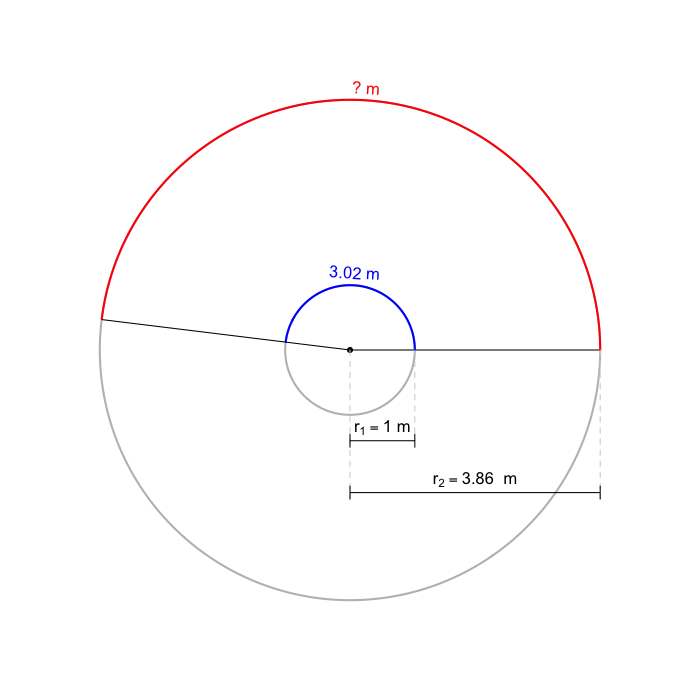

   What is the length, in meters, of the red arc? *The tolerance is set to $\pm0.01$ meters.*

#### Question

3. Two concentric circles have radii $r_1=1$ meters and $r_2=3.3$ meters. A central angle subtends similar arcs on both circles: a blue arc on the smaller circle and a red arc on the larger circle. The blue arc length is 4.52 meters, as shown in the diagram below.

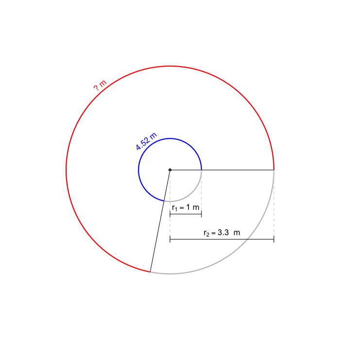

   What is the length, in meters, of the red arc? *The tolerance is set to $\pm0.01$ meters.*

#### Question

4. Two concentric circles have radii $r_1=1$ meters and $r_2=3.99$ meters. A central angle subtends similar arcs on both circles: a blue arc on the smaller circle and a red arc on the larger circle. The blue arc length is 1.01 meters, as shown in the diagram below.

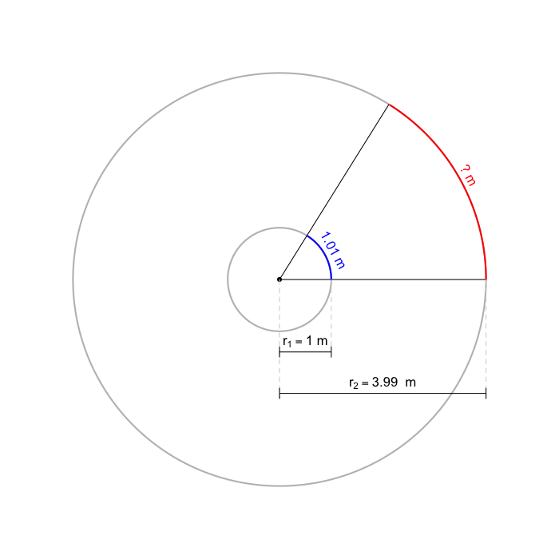

   What is the length, in meters, of the red arc? *The tolerance is set to $\pm0.01$ meters.*

#### Question

5. Two concentric circles have radii $r_1=1$ meters and $r_2=3.09$ meters. A central angle subtends similar arcs on both circles: a blue arc on the smaller circle and a red arc on the larger circle. The blue arc length is 4.03 meters, as shown in the diagram below.

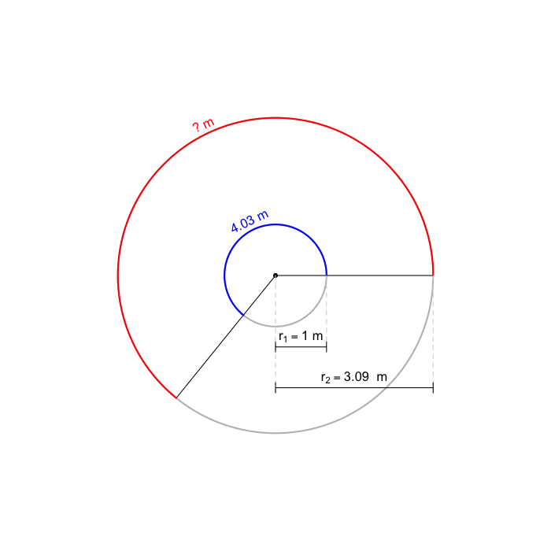

   What is the length, in meters, of the red arc? *The tolerance is set to $\pm0.01$ meters.*

#### Question

6. Two concentric circles have radii $r_1=1$ meters and $r_2=3.26$ meters. A central angle subtends similar arcs on both circles: a blue arc on the smaller circle and a red arc on the larger circle. The blue arc length is 2.25 meters, as shown in the diagram below.

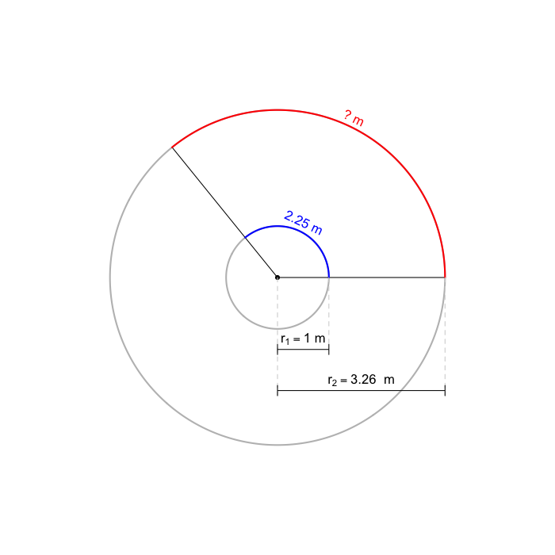

   What is the length, in meters, of the red arc? *The tolerance is set to $\pm0.01$ meters.*

#### Question

7. Two concentric circles have radii $r_1=1$ meters and $r_2=4.15$ meters. A central angle subtends similar arcs on both circles: a blue arc on the smaller circle and a red arc on the larger circle. The blue arc length is 2.62 meters, as shown in the diagram below.

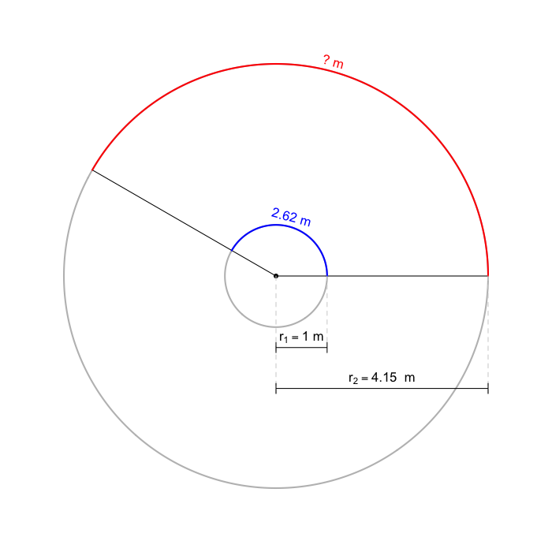

   What is the length, in meters, of the red arc? *The tolerance is set to $\pm0.01$ meters.*

#### Question

8. Two concentric circles have radii $r_1=1$ meters and $r_2=4.08$ meters. A central angle subtends similar arcs on both circles: a blue arc on the smaller circle and a red arc on the larger circle. The blue arc length is 2.06 meters, as shown in the diagram below.

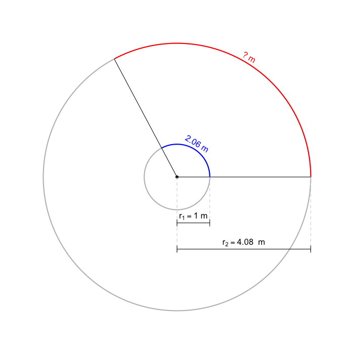

   What is the length, in meters, of the red arc? *The tolerance is set to $\pm0.01$ meters.*